# Taller 1: CRÍTICA VISUALIZACIÓN DE DATOS

### Con base en las siguientes visualizaciones se identificará los elementos basados en el framework de Tamara y bajo los siguientes criterios:

1. Abstraer ¿qué?, ¿por qué? y ¿cómo?
2. Marcas y canales utilizados
3. Cumple o no cumple alguna de las reglas generales descritas
4. Mejoras posibles, en cuánto a marcas o canales, que le realizaría a la visualización

Visualización # 1, el impacto promedio de los gases de efecto invernadero (en kilogramos de $CO_{2}$) de obtener 50 gramos de proteína y porcentaje de alimentos desperdiciados o perdidos a nivel del consumidor, por categoría:

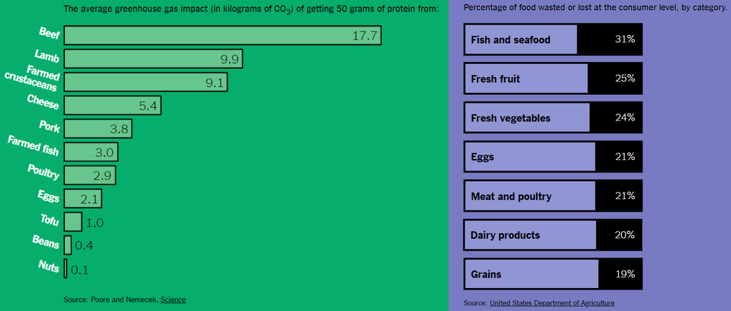

**1. Abstraer ¿qué?, ¿por qué? y ¿cómo?**

¿Qué?: Se obervan datos del impacto promedio de los gases de efecto invernadero (en kilogramos de 𝐶𝑂2 ) de obtener 50 gramos de proteína, en 11 tipos de proteinas, mostrando que la carne de res y cordero son las que tiene mas impacto de gases de efecto invernadero y en menor medida son los frijoles y las neuces, por otro lado en la gráfica del porcentaje de alimentos desperdiciados o perdidos a nivel del consumidor, por categoría co nmayor afectación es percados y mariscos en un 31% y en menor medida los granos con un 19%.

Muestra las categorias bajo los atributos repectivos y son estaticos ordenados.

¿Por qué?: Lo que seguramente conseguian para el usuario es dar a conocer el impacto de gases de efecto invernadero respecto a distintas proteinas, recalcando que hay algunas proteinas orgnicas mas afectadas que las vegetales.Dentro de las acciones de alto nivel se aprecia que para consumir, es decir, descubrir y presentar como tambien comparar el efecto del $CO_{2}$ en las distintas proteinas.

¿Cómo?: Representan el impacto medio que tien el $CO_{2}$ versus las proteinas mediante un gráfico de barras el cual es facil de entender y difenciar entre las categorias cuales son mas afectadas que otras por el orden que estable de mayor a menor afectacion de gases de efecto invernadero sobre las proteinas.

**2. Marcas y canales utilizados**

Las marcar utilizadas fueron lineas y los canales de posición horizontal de color verde, negro y morado. En la gráfica del efecto promedio de gases efecto invernadero versus las proteinas el tamaño va segun el largo que representaria los kilogramos en $CO_{2}$ y lo mismo en la gráfica de los alimentos que más se desperdician.

**3. Cumple o no cumple alguna de las reglas generales descritas**

Cumple con las reglas de no emplear 3d injustificado,, 2d injustificado, los ojos le ganan a la memoria y resolucion sobre la inmersión.

**4. Mejoras posibles, en cuánto a marcas o canales, que le realizaría a la visualización**

En cuanto a la marca de lineas(barras) estoy de aucerdo pero en el canal si cambiaria los colores de fondo ya que se mezclan con los colores que tiene las barras y hace poco visible y diferenciadoras las categorias.

## Visualización # 2, gasto militar por país

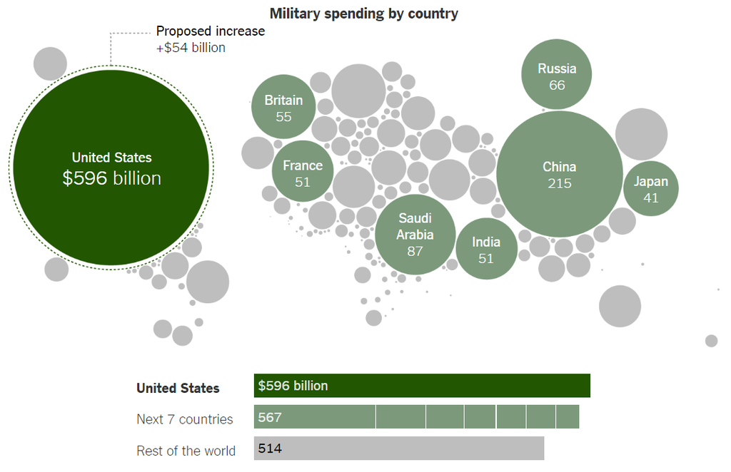

**1. Abstraer ¿qué?, ¿por qué? y ¿cómo?**

¿Qué?: Se oberva el gasto militar por país categorizado de mayor a menor, los globos más grandes muestran mayor gasto y los de menor tamaño menor inversión en gasto militar como los paises que son más representativos. Se observan los valores que se gastan siendo EEUU el país con mayor gasto militar seguido de China como de los 7 paises que le siguen a EEUU y por ultimos el gastao qeu sería en el resto de paises. Muestra a nivel de posición los gastos militares, el tipo de atributos son puntos, el tipo de dataset es geometrico como cluster porque se observa tres grupos de paises,

¿Por qué?: Lo que seguramente conseguian para el usuario es dar a conocer lso países que tienen mayor gasto militar y en que grupos se establecen como los monstos que invierten, permite comparar entre países sobre tod en el primer grupo (color verde), segundo grupo (verde claro ) y los de color gris.

¿Cómo?: se representa por medio de puntos que estan en función del gasto militar, es decir, a mayor gasto los puntos seran más grandes y mas pequeños si los países invierten menos en gasto miliatr, agrega por grupos (colores).

**2. Marcas y canales utilizados**

Las marcar utilizadas fueron puntos y los canales de volumen, shape y color. Muestra una escala para poder apreciar el valor invertido en gasto militar.

**3. Cumple o no cumple alguna de las reglas generales descritas**

Cumple con las reglas de no emplear 3d injustificado,, 2d injustificado, los ojos le ganan a la memoria y resolucion sobre la inmersión.

**4. Mejoras posibles, en cuánto a marcas o canales, que le realizaría a la visualización**

En cuanto a la marca de puntos estoy de aucerdo pero en el canal si colocaria algunos nombres de países en los puntos más grandes de color gris para tener una lectura más completa de los paises que se encuentran en este grupo de menor inversión en gasto militar pero que son muy altos si se observan dentro del grupo de paises de color gris.

#### Fuente

https://www.nytimes.com/2020/06/10/learning/over-60-new-york-times-graphs-for-students-to-analyze.html